# BayNorm exploration

# BayNorm

### Background

We observe transcript counts for a range of genes inside cells. However, the current methods used to measure counts have a low ‘capture efficiency’: proportion of the true value recorded, meaning observed counts are much lower than their true values and can often be zero/missing (dropouts).

The capture efficiency $\beta_{j}$ varies across cells j, but we assume that gene-specific effects are small (i.e. transcripts from any gene i have roughly proportion $\beta_{j}$ of being captured in cell j). The capture efficiency also varies between experiments, ‘batch-effects’, where different batches of cells have different capture rates due to many factors (environment, slight differences in experiment, time etc).

### Method

Use a bayesian approach to estimate posterior distribution of true/original transcript counts $x_{i,j}^{0}$.

Prior: assume the true counts $x_{i,j}^{0}$ follow negative binomial distribution with parameters $\mu_i$, $\phi_i$ estimated using counts for gene i across all cells (or cells in the same batch: ‘local’)

Likelihood: assume that the observed count $x_{i,j}$ follows a binomial distribution with N = $x_{i,j}^{0}$ and p = $\beta_j$ (natural choice: each transcript has chance $\beta_j$ of being observed)

This gives the posterior as a shifted negative-binomial distribution.

### Application

Given the posterior distribution of the true counts $x_{i,j}^{0}$ for each gene i in each cells j there are several choices on how to proceed.

1. MAP: ‘maximum a posteriori probability’, take the mode of the posterior as estimate of the true count $x_{i,j}^{0}$ for all i, j. This produces a ‘normalized’ dataset of the same size as the original, and can be put directly into the same analysis pipeline (bootstrap, truncate state space, solve LP to bound).
2. mean of posterior: as above, an estimate of the true count for each observed count
3. sample from posterior: for each (i, j) sample S count values from the posterior e.g. S = 20. This produces a dataset of the same size as the observed counts BUT each entry is a list of S samples from the corresponding posterior. These could be considered just as artifical cells, giving a dataset of 20 * the number of original cells to analyse (?).

# Estimating capture efficiencies: Beta

Using example data and code provided in bayNorm documentation:

```r
data('EXAMPLE_DATA_list')
rse <- SummarizedExperiment::SummarizedExperiment(
  assays=S4Vectors::SimpleList(counts=EXAMPLE_DATA_list$inputdata[,seq(1,30)])
)
rse
```

```
## class: SummarizedExperiment
## dim: 20 30
## metadata(0):
## assays(1): counts
## rownames(20): 0610009B22Rik 0610009D07Rik ... 1110008P14Rik
##   1110012L19Rik
## rowData names(0):
## colnames(30): SC_2i_1 SC_2i_2 ... SC_2i_30 SC_2i_31
## colData names(0):
```

```r
BETA_est<- bayNorm::BetaFun(Data=rse, MeanBETA = 0.06)
```

```
## Renaming the first element in assays(Data) to 'Counts'
```

```r
summary(BETA_est$BETA)
```

```
##    Min. 1st Qu.  Median    Mean 3rd Qu.    Max.
## 0.02299 0.03859 0.05255 0.06000 0.07473 0.11168
```

### Method to estimate beta

Set a value for the mean of $\beta$ = <$\beta$>, default 0.06 (i.e. average 6% capture efficiency). For each cell j sum the observed counts $x_{i,j}$ across all genes i (removing outliers and those with a high proportion of dropouts (zero values)), then normalise this vector to have mean = <$\beta$> giving $\beta$.

# Real data

Important to remove all missing values (NaN) otherwise the method will fail. Either drop genes/cells containing missing values, or preferably replace them by 0.

```r
# load 'cleaned' dataset:
# mean expression < 1 and sig. # missing values rows removed
data_counts <- read.csv("C:/Users/willi/Documents/Year 4 Project Work/Data/SS3_c57_UMIs_concat_cleaned.csv", row.names =  1)
# set all missing values to 0
data_counts[is.na(data_counts)] <- 0
head(data_counts, 5)
```

```
##               SS3_MAF_Leo171129_p2_S10 SS3_MAF_Leo171129_p2_S12
## 0610007P14Rik                        0                        2
## 0610009B22Rik                       10                        4
## 0610031J06Rik                       17                       18
## 1110007C09Rik                        1                        0
## 1110037F02Rik                        0                        0
##               SS3_MAF_Leo171129_p2_S13 SS3_MAF_Leo171129_p2_S14
## 0610007P14Rik                        2                        2
## 0610009B22Rik                        0                        0
## 0610031J06Rik                        9                       14
## 1110007C09Rik                        4                        9
## 1110037F02Rik                        4                        0
##               SS3_MAF_Leo171129_p2_S16 SS3_MAF_Leo171129_p2_S17
## 0610007P14Rik                        1                        4
## 0610009B22Rik                        0                       14
## 0610031J06Rik                        0                        9
## 1110007C09Rik                        0                        0
## 1110037F02Rik                        2                       10
##               SS3_MAF_Leo171129_p2_S18 SS3_MAF_Leo171129_p2_S19
## 0610007P14Rik                        4                        4
## 0610009B22Rik                       26                        6
## 0610031J06Rik                        6                       22
## 1110007C09Rik                        0                        0
## 1110037F02Rik                        0                        2
##               SS3_MAF_Leo171129_p2_S1 SS3_MAF_Leo171129_p2_S20
## 0610007P14Rik                       7                        2
## 0610009B22Rik                       1                        2
## 0610031J06Rik                       1                       10
## 1110007C09Rik                       0                        0
## 1110037F02Rik                       8                        0
##               SS3_MAF_Leo171129_p2_S21 SS3_MAF_Leo171129_p2_S22
## 0610007P14Rik                        7                        3
## 0610009B22Rik                       11                        2
## 0610031J06Rik                       12                        5
## 1110007C09Rik                        7                        0
## 1110037F02Rik                        4                        2
##               SS3_MAF_Leo171129_p2_S23 SS3_MAF_Leo171129_p2_S24
## 0610007P14Rik                        1                        1
## 0610009B22Rik                        4                        0
## 0610031J06Rik                       21                        8
```

[output cut: 617 more lines]

```
## 0610031J06Rik                         8                        31
## 1110007C09Rik                         0                         0
## 1110037F02Rik                         4                         3
##               SS3_MAF_leo180223_p4_S188 SS3_MAF_leo180223_p4_S190
## 0610007P14Rik                         4                         0
## 0610009B22Rik                         1                         4
## 0610031J06Rik                        15                         1
## 1110007C09Rik                         5                         0
## 1110037F02Rik                         6                         0
##               SS3_MAF_leo180223_p4_S98 SS3_MAF_leo180223_p4_S99
## 0610007P14Rik                        0                        0
## 0610009B22Rik                        3                        2
## 0610031J06Rik                        1                        2
## 1110007C09Rik                        2                        0
## 1110037F02Rik                        0                        3
```

```r
# estimate beta
BETA_est<- bayNorm::BetaFun(Data=data_counts, MeanBETA = 0.06)
summary(BETA_est$BETA)
```

```
##    Min. 1st Qu.  Median    Mean 3rd Qu.    Max.
## 0.00957 0.03431 0.05865 0.06000 0.07779 0.21341
```

```r
# MAP of posterior for each data  entry
bayNorm_2D<-bayNorm(
    Data=data_counts,
    BETA_vec = NULL,
    mode_version=TRUE,
    mean_version = FALSE,
    verbose =TRUE,
    parallel = TRUE)
```

```
## Priors estimation based on MME method has completed.
```

```
## Start optimization using spg from BB package.
## This part may be time-consuming.
```

```
## Prior estimation has completed!
```

```r
data_MAP <- data.frame(bayNorm_2D$Bay_out)
head(data_MAP, 5)
```

```
##               SS3_MAF_Leo171129_p2_S10 SS3_MAF_Leo171129_p2_S12
## 0610007P14Rik                        1                       22
## 0610009B22Rik                      133                       49
## 0610031J06Rik                      272                      230
## 1110007C09Rik                       12                        0
## 1110037F02Rik                        6                        5
##               SS3_MAF_Leo171129_p2_S13 SS3_MAF_Leo171129_p2_S14
## 0610007P14Rik                       23                       24
## 0610009B22Rik                       10                       10
## 0610031J06Rik                      139                      205
## 1110007C09Rik                       48                      114
## 1110037F02Rik                       44                        5
##               SS3_MAF_Leo171129_p2_S16 SS3_MAF_Leo171129_p2_S17
## 0610007P14Rik                       13                       21
## 0610009B22Rik                       11                       75
## 0610031J06Rik                       34                       60
## 1110007C09Rik                        0                        0
## 1110037F02Rik                       27                       51
##               SS3_MAF_Leo171129_p2_S18 SS3_MAF_Leo171129_p2_S19
## 0610007P14Rik                       29                       35
## 0610009B22Rik                      186                       58
## 0610031J06Rik                       62                      224
## 1110007C09Rik                        0                        0
## 1110037F02Rik                        3                       19
##               SS3_MAF_Leo171129_p2_S1 SS3_MAF_Leo171129_p2_S20
## 0610007P14Rik                      76                       16
## 0610009B22Rik                      20                       22
## 0610031J06Rik                      41                      105
## 1110007C09Rik                       0                        0
## 1110037F02Rik                      80                        4
##               SS3_MAF_Leo171129_p2_S21 SS3_MAF_Leo171129_p2_S22
## 0610007P14Rik                       51                       43
## 0610009B22Rik                       84                       39
## 0610031J06Rik                      109                      116
## 1110007C09Rik                       53                        0
## 1110037F02Rik                       30                       30
##               SS3_MAF_Leo171129_p2_S23 SS3_MAF_Leo171129_p2_S24
## 0610007P14Rik                       14                       16
## 0610009B22Rik                       61                       13
## 0610031J06Rik                      334                      171
```

[output cut: 617 more lines]

```
## 0610031J06Rik                       113                       294
## 1110007C09Rik                         0                         0
## 1110037F02Rik                        40                        26
##               SS3_MAF_leo180223_p4_S188 SS3_MAF_leo180223_p4_S190
## 0610007P14Rik                        40                         1
## 0610009B22Rik                        18                        59
## 0610031J06Rik                       184                        48
## 1110007C09Rik                        53                         0
## 1110037F02Rik                        57                         6
##               SS3_MAF_leo180223_p4_S98 SS3_MAF_leo180223_p4_S99
## 0610007P14Rik                        2                        2
## 0610009B22Rik                       59                       48
## 0610031J06Rik                       64                       91
## 1110007C09Rik                       34                        0
## 1110037F02Rik                        7                       50
```

The above dataframe shows the upscaled/normalized data produced using the MAP of the posterior. Comparing to the observed counts dataframe above we see that counts have been generally increased, but not by simply globally scaling by a constant, instead using more information.

Store data

```r
# write.csv(data_MAP, "SS3_c57_UMIs_concat_MAP.csv")
```

# Data analysis

Compare the distribution of transcript counts for genes to the distribution of the normalized transcript counts (MAP estimates).

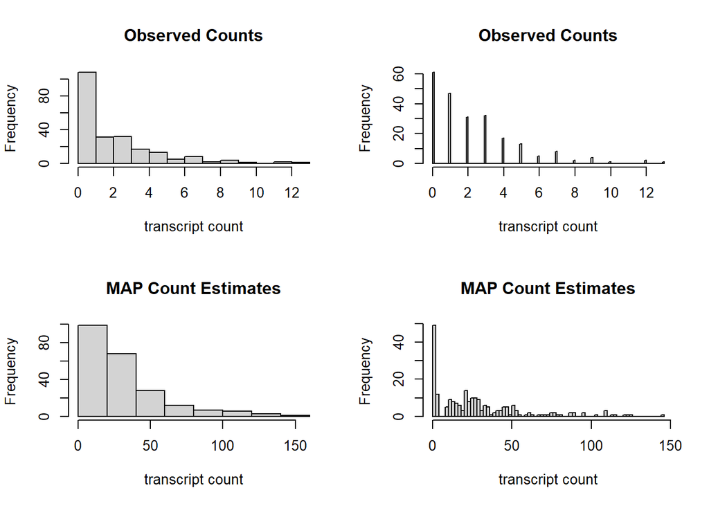

```r
# first gene
par(mfrow=c(2,2))
# histogram of observed counts
hist(as.numeric(data_counts[1,]), breaks=10, main="Observed Counts",
     xlab = "transcript count")
hist(as.numeric(data_counts[1,]), breaks=100, main="Observed Counts",
     xlab = "transcript count")
# histogram of MAP counts
hist(as.numeric(data_MAP[1,]), breaks=10, main="MAP Count Estimates",
     xlab = "transcript count")
hist(as.numeric(data_MAP[1,]), breaks=100, main="MAP Count Estimates",
     xlab = "transcript count")
```

See that the general shape of the distribution remains the same, and still have a high proportion of counts = 0, but the counts are scaled to much higher values (max of ~150 from ~12) with many more unique count values.

Even with an ‘input’ (observed count data) that has few counts with no observations, the ‘output’ (MAP count data) has several count values (in the range 0-150) with no observations. This could be an issue when directly using MAP data in the LP methods, since CI’s for these states (count values) cannot be estimated (are [0, 0]) and so must be set to [0, 1].

We plot comparisons of ‘input’ and ‘output’ distributions for a random selection of genes to see if this holds in general:

```
## [1] 491
```

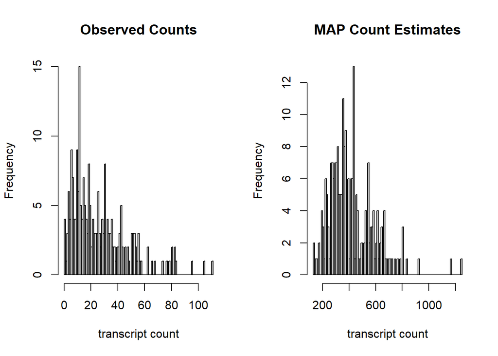

```
## [1] 3721
```

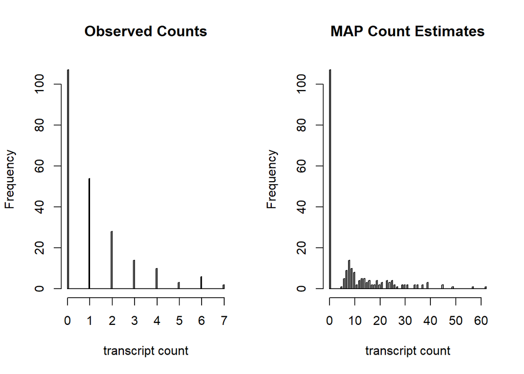

```
## [1] 3402
```

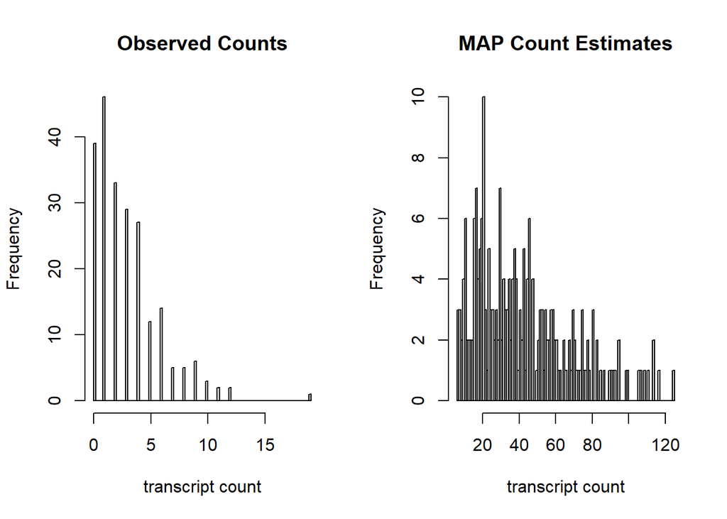

```
## [1] 368
```

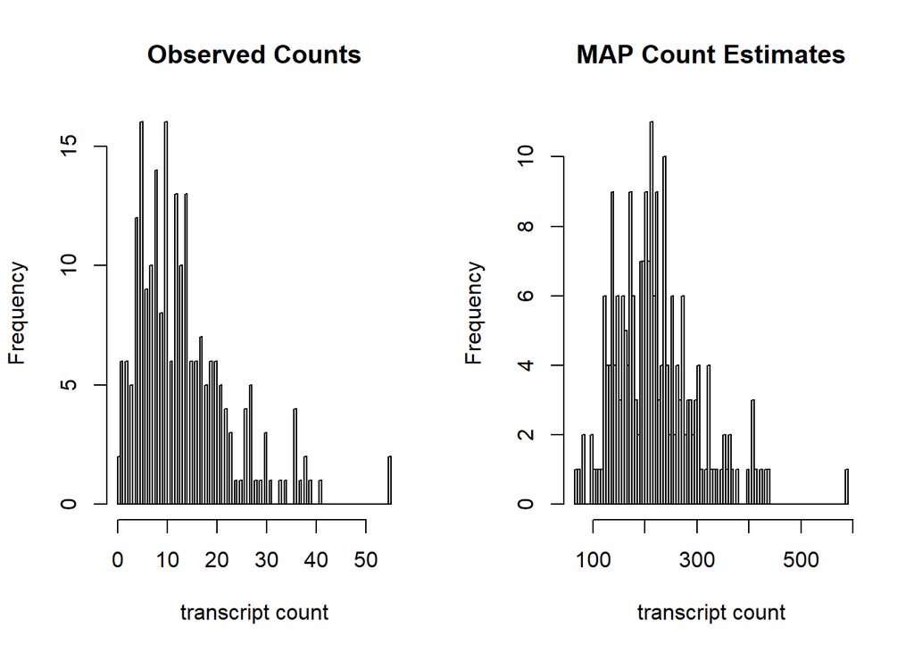

```
## [1] 1484
```

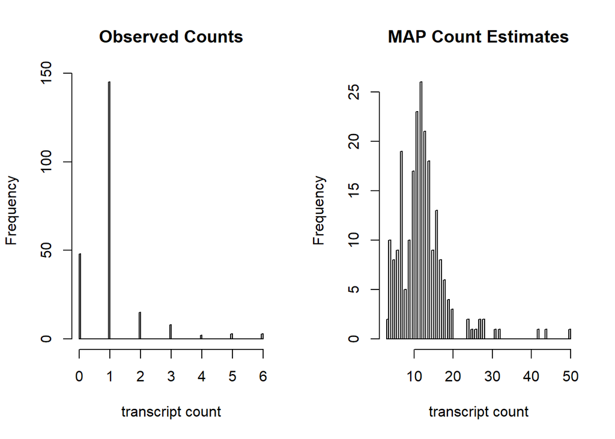

```r
set.seed(10)
# number of genes
n <- 5
for (i in 1:n) {
  par(mfrow=c(1,2))
  # random gene
  j <- sample.int(dim(data_counts)[1], 1)
  print(j)
  # histogram of observed counts
  hist(as.numeric(data_counts[j,]), breaks=100, main="Observed Counts",
       xlab = "transcript count")
  # histogram of MAP counts
  hist(as.numeric(data_MAP[j,]), breaks=100, main="MAP Count Estimates",
       xlab = "transcript count")
}
```

# Sample from posterior

```r
# S = 20 samples from posterior for each data  entry
bayNorm_3D<-bayNorm(
    Data=data_counts,
    BETA_vec = NULL,
    mode_version=FALSE,
    mean_version = FALSE,
    S = 20,
    verbose =TRUE,
    parallel = TRUE)
```

```
## Priors estimation based on MME method has completed.
```

```
## Start optimization using spg from BB package.
## This part may be time-consuming.
```

```
## Prior estimation has completed!
```

```r
data_samples <- data.frame(bayNorm_3D$Bay_out)
print(dim(data_samples))
```

```
## [1] 3875 4480
```

```r
head(data_samples, 5)
```

```
##               SS3_MAF_Leo171129_p2_S10.1 SS3_MAF_Leo171129_p2_S12.1
## 0610007P14Rik                          2                         60
## 0610009B22Rik                        121                         59
## 0610031J06Rik                        234                        268
## 1110007C09Rik                         79                         11
## 1110037F02Rik                         20                          0
##               SS3_MAF_Leo171129_p2_S13.1 SS3_MAF_Leo171129_p2_S14.1
## 0610007P14Rik                         54                         46
## 0610009B22Rik                         30                         15
## 0610031J06Rik                        195                        198
## 1110007C09Rik                         34                        106
## 1110037F02Rik                         79                         21
##               SS3_MAF_Leo171129_p2_S16.1 SS3_MAF_Leo171129_p2_S17.1
## 0610007P14Rik                         26                          8
## 0610009B22Rik                         42                         61
## 0610031J06Rik                         56                         44
## 1110007C09Rik                          2                          1
## 1110037F02Rik                         17                         93
##               SS3_MAF_Leo171129_p2_S18.1 SS3_MAF_Leo171129_p2_S19.1
## 0610007P14Rik                         35                         19
## 0610009B22Rik                        230                         58
## 0610031J06Rik                        113                        203
## 1110007C09Rik                          0                          7
## 1110037F02Rik                         14                         24
##               SS3_MAF_Leo171129_p2_S1.1 SS3_MAF_Leo171129_p2_S20.1
## 0610007P14Rik                       106                         17
## 0610009B22Rik                        39                         54
## 0610031J06Rik                        76                         85
## 1110007C09Rik                        11                          4
## 1110037F02Rik                        47                          8
##               SS3_MAF_Leo171129_p2_S21.1 SS3_MAF_Leo171129_p2_S22.1
## 0610007P14Rik                         75                         64
## 0610009B22Rik                        115                         30
## 0610031J06Rik                        142                        144
## 1110007C09Rik                         71                         11
## 1110037F02Rik                         35                         35
##               SS3_MAF_Leo171129_p2_S23.1 SS3_MAF_Leo171129_p2_S24.1
## 0610007P14Rik                         33                          8
## 0610009B22Rik                        143                         15
## 0610031J06Rik                        504                        151
```

[output cut: 13385 more lines]

```
## 0610031J06Rik                          165                          358
## 1110007C09Rik                            1                            2
## 1110037F02Rik                           77                           29
##               SS3_MAF_leo180223_p4_S188.20 SS3_MAF_leo180223_p4_S190.20
## 0610007P14Rik                           55                           25
## 0610009B22Rik                           38                           48
## 0610031J06Rik                          165                           57
## 1110007C09Rik                           99                           19
## 1110037F02Rik                           67                           12
##               SS3_MAF_leo180223_p4_S98.20 SS3_MAF_leo180223_p4_S99.20
## 0610007P14Rik                          18                          23
## 0610009B22Rik                          92                          53
## 0610031J06Rik                         173                         226
## 1110007C09Rik                          36                           9
## 1110037F02Rik                          36                          37
```

```r
# store data
# write.csv(data_samples, "SS3_c57_UMIs_concat_PosteriorSamples.csv")
```

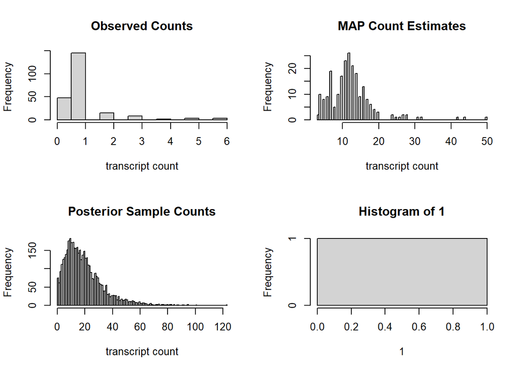

```r
# gene
par(mfrow=c(2,2))
j <- 1484
# histogram of observed counts
hist(as.numeric(data_counts[j,]), breaks=10, main="Observed Counts",
     xlab = "transcript count")
# histogram of MAP counts
hist(as.numeric(data_MAP[j,]), breaks=100, main="MAP Count Estimates",
     xlab = "transcript count")
# histogram of posterior sample counts
hist(as.numeric(data_samples[j,]), breaks=100, main="Posterior Sample Counts",
     xlab = "transcript count")
hist(1)
```

# Misc. code

```r
# array from dataframe
data_array <- array(
  data = unlist(data_counts[seq(1,30),seq(1,30)]),
  dim = dim(data_counts[seq(1,30),seq(1,30)]),
  dimnames = list(
    rownames(data_counts[seq(1,30),seq(1,30)]),
    colnames(data_counts[seq(1,30),seq(1,30)])
  )
)

# summarized experiment from array
rse_data = SummarizedExperiment::SummarizedExperiment(
  assays = list(counts = data_array),
)
rse_data
```

```
## class: SummarizedExperiment
## dim: 30 30
## metadata(0):
## assays(1): counts
## rownames(30): 0610007P14Rik 0610009B22Rik ... 2200002D01Rik
##   2210013O21Rik
## rowData names(0):
## colnames(30): SS3_MAF_Leo171129_p2_S10 SS3_MAF_Leo171129_p2_S12 ...
##   SS3_MAF_Leo171129_p2_S43 SS3_MAF_Leo171129_p2_S44
## colData names(0):
```